# Should the SPM analyses be normalised by time or by knee angle?

Both SPM families re-run on three abscissae over identical repetitions. The between-modality torque conclusion changes qualitatively; the progression conclusion mostly does not.

jHamON training study · NH vs IK · branch `angle-normalised-spm` · generated by `compare_axes.py` from `axis_comparison.json`

Torque, time axis

2 clusters

IK>NH 0–28.3% and NH>IK 72.3–99.7% — a biphasic story

Torque, knee-angle axis

1 cluster

NH>IK across the whole 80–30° range, p < 0.001. The "IK stronger early" cluster is gone

Angle mismatch at the same node

37.8°

peak difference in knee angle between the groups at an identical time node (node 78)

Velocity crossover

~62°

moves from ≈75% of duration to 62° of flexion — roughly a third of the way through the range, not the final fifth

## 1. Why the axis matters here

Every curve in the caches is linearly **time**-normalised to 101 nodes, and every SPM result in the project is computed on that axis. Time is only a fair common reference if both modalities advance through their range of motion at the same rate. They do not — and that is by design, not by accident.

A Nordic descent is an accelerating fall: the participant resists almost isometrically at first, then gives way. An isokinetic repetition is held at constant angular velocity by the dynamometer. Measured on the group-mean trajectories, the Nordic angle-versus-time curve departs from a straight line by **28.9°** (37.3% of its range of motion); the isokinetic one by **6.7°** (8.6%, essentially the dynamometer's acceleration and deceleration ramps).

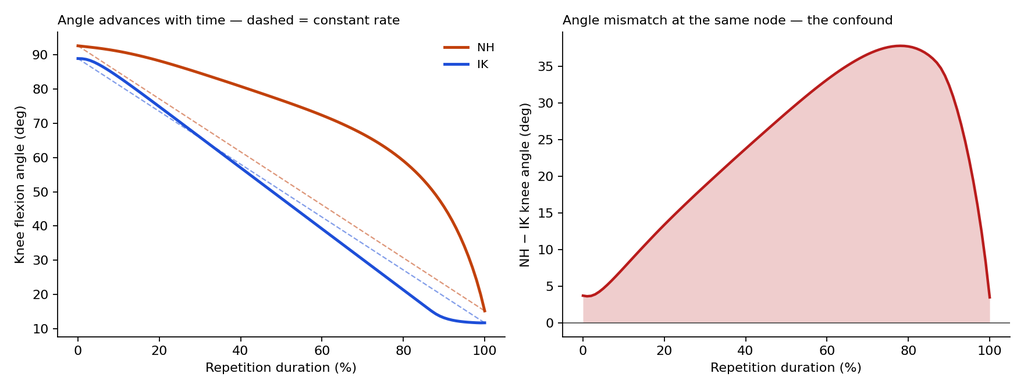

**Left:** how knee angle advances with time in each group; dashed lines show what a constant-rate movement would look like. **Right:** the difference in knee angle between the groups at the same time node — the quantity that gets confounded with modality.

What the same time node means in each group

| Node (% of duration) | 0 | 10 | 20 | 30 | 40 | 50 | 60 | 70 | 80 | 90 | 100 |
| --- | --- | --- | --- | --- | --- | --- | --- | --- | --- | --- | --- |
| **NH** knee angle (deg) | 92.6 | 91.0 | 88.3 | 84.7 | 80.8 | 76.7 | 72.3 | 66.9 | 59.0 | 45.6 | 15.2 |
| **IK** knee angle (deg) | 88.9 | 83.5 | 74.9 | 65.9 | 57.0 | 48.1 | 39.2 | 30.2 | 21.3 | 13.2 | 11.7 |
| **NH − IK** mismatch (deg) | +3.7 | +7.5 | +13.4 | +18.7 | +23.8 | +28.7 | +33.2 | +36.7 | +37.7 | +32.5 | +3.5 |

#### The consequence

At the midpoint of the repetition the Nordic knee is at 76.7° and the isokinetic knee at 48.1°. Nordic participants have travelled about a fifth of their range; isokinetic participants about half. Knee-flexor torque is strongly angle-dependent, so a between-modality test on the time axis compares torque at one joint angle against torque at another and reports the difference as an effect of modality.

## 2. What changes: between-modality contrast

All three abscissae are run on the **same repetitions** — the intersection of those registrable on every axis (15,663 for torque) — so a moved cluster cannot be a changed sample. `rom_percent` is the control: it has the same node count as the time axis, truncates nothing and drops no repetition, so any difference against `time` isolates the abscissa from every other change.

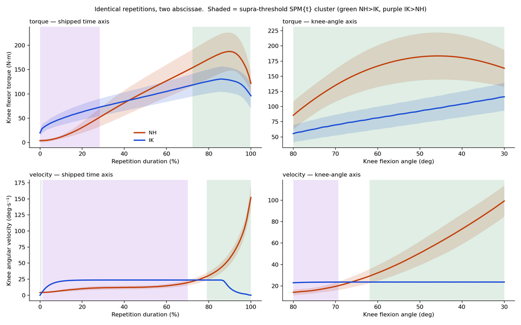

Identical repetitions, two abscissae. Shading marks supra-threshold SPM{t} clusters (green NH>IK, purple IK>NH); bands are ±1 SD between participants.

Torque — NH vs IK, one curve per participant (13 vs 14), α = 0.05 two-tailed

| Abscissa | t* | df | FWHM | nodes | Supra-threshold clusters |
| --- | --- | --- | --- | --- | --- |
| **Time (% of duration)** the shipped axis | 2.974 | 24.8 | 31.8 | 101 | **IK>NH** 0→28.3% p = 0.003 **NH>IK** 72.3→99.7% p = 0.003 |
| **Angle (% of own ROM)** same node count, nothing truncated | 3.020 | 24.2 | 29.0 | 101 | **IK>NH** 0→7%ROM p = 0.040 **NH>IK** 14.1→85.2%ROM p < 0.001 |
| **Knee angle (deg)** anatomically interpretable | 2.634 | 20.3 | 44.5 | 51 | **NH>IK** 80→30deg p < 0.001 |

#### The biphasic torque result does not survive

On the time axis the curves cross at about 42% and produce two clusters — read as "isokinetic torque is higher early, Nordic torque higher late". On the knee-angle axis there is a single cluster: **NH > IK across the entire 80–30° range**, p < 0.001. The Nordic curve is never below the isokinetic one at a matched joint angle.

The control confirms this is re-alignment and not truncation: on `rom_percent`, which keeps the whole movement, the IK>NH cluster shrinks from 28.3% of the curve to just 7%, and the NH>IK cluster expands to 14.1–85.2%.

Mechanistically the artefact is easy to state: over the first quarter of the repetition a Nordic participant has barely moved and is still in the *onset transient* of the torque trace, while the dynamometer has already swept ~21° and reached its plateau. The time axis lines those two phases up and calls the difference an effect of modality.

Knee angular velocity — NH vs IK, one curve per participant (13 vs 14), α = 0.05 two-tailed

| Abscissa | t* | df | FWHM | nodes | Supra-threshold clusters |
| --- | --- | --- | --- | --- | --- |
| **Time (% of duration)** the shipped axis | 3.608 | 12.2 | 19.4 | 101 | **NH>IK** 0→0.7% p = 0.050 **IK>NH** 1.2→70.1% p < 0.001 **NH>IK** 79.1→100% p < 0.001 |
| **Angle (% of own ROM)** same node count, nothing truncated | 3.600 | 12.3 | 19.2 | 101 | **IK>NH** 0.3→29.6%ROM p < 0.001 **NH>IK** 41→100%ROM p < 0.001 |
| **Knee angle (deg)** anatomically interpretable | 3.187 | 12.0 | 21.1 | 51 | **IK>NH** 80→69.3deg p = 0.017 **NH>IK** 61.9→30deg p < 0.001 |

For velocity the direction of the conclusion survives but its **location** moves substantially. On the time axis the crossover sits at roughly 75% of the duration, which reads as "the Nordic group is faster only in the final fifth". On the angle axis the crossover is at about 62° of flexion — roughly a third of the way through the range — so the Nordic group exceeds the prescribed isokinetic speed over most of the movement. That bears directly on the velocity-matching claim the design rests on.

Group means at matched joint angles — only quotable once the abscissa is shared

| Variable | Group | 80° | 70° | 60° | 50° | 40° | 30° |
| --- | --- | --- | --- | --- | --- | --- | --- |
| torque (N·m) | **NH** | 85.7 | 135.1 | 166.8 | 182.0 | 180.8 | 163.3 |
| torque (N·m) | **IK** | 55.4 | 69.8 | 81.2 | 92.6 | 104.3 | 116.2 |
| torque | **NH − IK** | +30.3 | +65.3 | +85.6 | +89.4 | +76.5 | +47.1 |
| velocity (deg·s⁻¹) | **NH** | 14.1 | 19.6 | 32.2 | 50.6 | 73.1 | 99.2 |
| velocity (deg·s⁻¹) | **IK** | 23.0 | 23.6 | 23.6 | 23.7 | 23.7 | 23.6 |
| velocity | **NH − IK** | -8.9 | -4.0 | +8.5 | +27.0 | +49.5 | +75.6 |

## 3. Robustness

### Does the grid choice drive it?

The absolute-angle grid necessarily discards repetitions that do not span it, so the window is a coverage-versus-interpretability trade-off. The primary 80–30° window keeps 97% of Nordic and 100% of isokinetic repetitions. The torque conclusion is identical on every window tried, including ones that keep only 42% of the Nordic repetitions.

Torque — does the angle-axis result depend on where the grid is cut?

| Grid | NH kept | IK kept | t* | Supra-threshold clusters |
| --- | --- | --- | --- | --- |
| **80-30 deg** | 97% | 100% | 2.634 | **NH>IK** 80→30deg p < 0.001 |
| **85-25 deg** | 87% | 100% | 2.728 | **NH>IK** 82.9→25deg p < 0.001 |
| **88-20 deg** | 64% | 93% | 2.795 | **NH>IK** 83.2→23.1deg p < 0.001 |
| **88-15 deg** | 42% | 86% | 2.832 | **NH>IK** 81.9→22.2deg p < 0.001 |

Knee angular velocity — does the angle-axis result depend on where the grid is cut?

| Grid | NH kept | IK kept | t* | Supra-threshold clusters |
| --- | --- | --- | --- | --- |
| **80-30 deg** | 97% | 100% | 3.187 | **IK>NH** 80→69.3deg p = 0.017 **NH>IK** 61.9→30deg p < 0.001 |
| **85-25 deg** | 87% | 100% | 3.293 | **IK>NH** 85→69.4deg p = 0.004 **NH>IK** 62→25deg p < 0.001 |
| **88-20 deg** | 64% | 93% | 3.404 | **IK>NH** 88→69.6deg p < 0.001 **NH>IK** 61.9→20deg p < 0.001 |
| **88-15 deg** | 42% | 86% | 3.482 | **IK>NH** 88→69deg p < 0.001 **NH>IK** 61.2→15deg p < 0.001 |

### Does the exclusion rule drive it?

No. With no exclusions at all and with the corrected repetition-level exclusions, the between-modality clusters agree to within a few tenths of a percent:

- Torque, knee angle — no exclusions: NH>IK 80-30deg (p <0.001); corrected exclusions: NH>IK 80-30deg (p <0.001)
- Velocity, knee angle — no exclusions: IK>NH 80-69.3deg (p = 0.017) | NH>IK 61.9-30deg (p <0.001); corrected exclusions: IK>NH 80-69.3deg (p = 0.017) | NH>IK 61.9-30deg (p <0.001)

### Is the angle trace invertible?

Angle normalisation requires inverting angle(*t*), so the trace must not reverse. It effectively never does: the median repetition has 0.0000 of its range in upward travel (NH) and 0.0000 (IK), and only 1.03% of Nordic and 0.19% of isokinetic repetitions exceed 10%.

## 4. What changes: within-group progression

Here the answer is more mixed, and the honest summary is that **the axis matters much less than it does for the between-modality contrast**.

NH torque progression — session 1 vs each later session, paired SPM{t}, α = 0.05 uncorrected

| Abscissa | sig. | first sustained | significant sessions | session 1 vs 15 |
| --- | --- | --- | --- | --- |
| **Time (% of duration)** | 9/14 | session 10 | 2, 4, 8, 10, 11, 12, 13, 14, 15 | **s15>s1** 85.3→96.6% p = 0.004 |
| **Angle (% of own ROM)** | 6/14 | session 10 | 10, 11, 12, 13, 14, 15 | **s15>s1** 51.1→79.8%ROM p < 0.001 |
| **Knee angle (deg)** | 9/14 | session 10 | 2, 3, 4, 10, 11, 12, 13, 14, 15 | **s15>s1** 61.9→35.3deg p < 0.001 |

IK torque progression — session 1 vs each later session, paired SPM{t}, α = 0.05 uncorrected

| Abscissa | sig. | first sustained | significant sessions | session 1 vs 15 |
| --- | --- | --- | --- | --- |
| **Time (% of duration)** | 13/14 | session 3 | 3, 4, 5, 6, 7, 8, 9, 10, 11, 12, 13, 14, 15 | **s15>s1** 20.9→100% p < 0.001 |
| **Angle (% of own ROM)** | 13/14 | session 3 | 3, 4, 5, 6, 7, 8, 9, 10, 11, 12, 13, 14, 15 | **s15>s1** 18.6→100%ROM p < 0.001 |
| **Knee angle (deg)** | 7/14 | session 12 | 7, 8, 10, 12, 13, 14, 15 | **s15>s1** 75.6→30deg p < 0.001 |

NH torque progression — session 1 vs each later session, paired SPM{t}, α = 0.05/14 Bonferroni

| Abscissa | sig. | first sustained | significant sessions | session 1 vs 15 |
| --- | --- | --- | --- | --- |
| **Time (% of duration)** | 3/14 | none | 11, 12, 13 | no supra-threshold cluster |
| **Angle (% of own ROM)** | 0/14 | none | — | no supra-threshold cluster |
| **Knee angle (deg)** | 2/14 | none | 12, 13 | no supra-threshold cluster |

IK torque progression — session 1 vs each later session, paired SPM{t}, α = 0.05/14 Bonferroni

| Abscissa | sig. | first sustained | significant sessions | session 1 vs 15 |
| --- | --- | --- | --- | --- |
| **Time (% of duration)** | 8/14 | session 9 | 7, 9, 10, 11, 12, 13, 14, 15 | **s15>s1** 31.2→100% p < 0.001 |
| **Angle (% of own ROM)** | 7/14 | session 11 | 7, 9, 11, 12, 13, 14, 15 | **s15>s1** 30.3→100%ROM p < 0.001 |
| **Knee angle (deg)** | 3/14 | session 13 | 13, 14, 15 | **s15>s1** 65.9→30deg p < 0.001 |

#### Reading these

**Nordic:** the count of significant sessions and the onset of a sustained effect are the same on time and on angle (9/14, sustained from session 10). What changes is *where* the effect is located and how interpretable that location is: the time axis puts the session-1-vs-15 cluster at 85–97% of the duration, the angle axis puts it at 62–35° of flexion — a statement about the joint rather than about the clock.

**Isokinetic:** time and `rom_percent` agree exactly (13/14), which is precisely what should happen when the dynamometer fixes the tempo and the two axes are near-affine. The drop to 7/14 on the absolute-angle grid is mostly **truncation**: the time-axis clusters extend to 100%, i.e. into the terminal ramp that the 80–30° window excludes. This is a real cost of the absolute grid and should be reported as such rather than presented as a weaker effect.

**Both groups, Bonferroni:** the correction the Methods promise leaves very little standing on any axis (NH 3/14 → 2/14, IK 8/14 → 3/14). That is a finding about the correction, not about the abscissa.

## 5. Two code defects found on the way

Both are in `jhamon_training/data/utils.py:dame_manual_exclusions` and both are corrected on this branch, with the original behaviour retained behind `legacy=True` so published numbers stay reproducible.

1. **Exclusions were scoped to a variable, not to a repetition.** The filters collect the offending rows' `all_labels`, but `frames.py` builds that label from `par trses set rep var tr_group` — the variable name is part of it. Only the flagged variable's rows were dropped, so a Nordic repetition rejected for an impossible starting knee angle kept contributing its torque curve. On the current caches that meant 12 827 Nordic `knee_ROM` rows removed against 2 727 `torque` rows: three different effective samples depending on which variable an analysis read.
2. **The isokinetic angle threshold predated the sign convention.** `IKfilt_knee2` tested `knee_ROM` at node 100 for `> -70`, written when isokinetic angles were stored negative. `frames.ikt_todf` now emits `90 - abs(value)` (≈ +11.7° at the end), so every value passes the test: the filter matched **100% of isokinetic repetitions** (9 932 of 9 932) and deleted the entire isokinetic angle dataset. Defect 1 concealed it — isokinetic torque and velocity survived untouched, so nothing downstream failed. It only surfaces when an analysis needs isokinetic `knee_ROM`, which angle normalisation does.

A third criterion, `knee_ROM` at node 50 `> 50` for the isokinetic group, was deliberately **not** carried over. It was also written for the old convention, under which it was inert and has never excluded a repetition in any published run. Under the current convention it would sit at the exact midpoint of a normal sweep (a linear 88.9 → 11.7° descent passes 50.3° halfway) and discard 9.1% of ordinary repetitions — reinstating it would invent a behaviour rather than restore one.

Net effect of the correction: Nordic 5,951 → 5,723 repetitions, isokinetic 9,932 → 9,804, applied consistently across every variable.

## 6. Recommendation

- **Between modalities: make knee angle primary.** The claim is about the mechanical stimulus delivered to the hamstrings, hamstring torque is angle-dependent, and the two modalities traverse the range at deliberately different rates. Report the 80–30° window (97%/100% coverage) with `rom_percent` as the sensitivity check.
- **Keep the time axis as a supplementary result**, framed as what it is — a description of the temporal profile. It remains the right axis for anything about rate of force development or tempo.
- **Progression: report on angle for interpretability**, but state plainly that the conclusion is axis-insensitive for the Nordic group and that the isokinetic drop on the absolute grid is truncation. Do not present it as a change in findings.
- **The Results sentence quoting "isokinetic torque ≈59% higher over the first 28%" must go.** It is an artefact of comparing a torque onset transient against an established plateau.
- **The Methods paragraph needs rewriting.** It currently concedes that "matched percentages do not correspond to identical knee angles" and then reports the angular ranges alongside each result. Mapping cluster boundaries to angles after the fact does not repair the inference — the test itself was computed at mismatched angles.

#### Outstanding: angular resolution

The caches store only the 101-point time-normalised curves, so the angle registrations here are resampled from those rather than from raw signal. Where a Nordic descent is fastest — the last tenth of its duration — consecutive time nodes are about 3° apart, so angular resolution near full extension is coarser than the 1° grid implies. Everything above is robust to the grid, but a definitive version should re-derive the curves from `/Volumes/AJMA` at full sample rate. `jhamon_training.curves` is agnostic about provenance, so that requires no change to the analysis code.